# Regressão Logistíca - AD2

Ygor Santos

2 de maio de 2016

## Análise e Previsões da Votação do Impeachment

O objetivo dessa atividade é analisar os dados referentes aos deputados envolvidos na votação do impeachment da presidente Dilme e, a partir disso, tentar gerar um modelo que possa predizer o voto dos deputados baseados em algumas váriaveis que irei selecionar de acordo com sua relevância.

```r
#leitura dos dados
dados <- read.csv2("~/ad2/Problema_5/data/deputados_temas_e_impeachment.csv", encoding="UTF-8")
```

## Análise Descritiva

```r
#sumario dos dados
summary(dados, na.rm=T)
```

```
##      id_dep                    nome                 deputado
##  Min.   :  4930   AlessandroMolon:  2   Alessandro Molon:  2
##  1st Qu.: 74765   AlielMachado   :  2   Aliel Machado   :  2
##  Median :160552   CiceroAlmeida  :  2   Cícero Almeida  :  2
##  Mean   :138959   ElizeuDionizio :  2   Elizeu Dionizio :  2
##  3rd Qu.:178873   ElizianeGama   :  2   Eliziane Gama   :  2
##  Max.   :191923   GlauberBraga   :  2   (Other)         :470
##  NA's   :3        (Other)        :528   NA's            : 60
##     partido          UF            tema_1          tema_2
##  pmdb   : 68   SP     : 72            :  6            :  6
##  pt     : 66   MG     : 53   abstenção:  4   abstc¸a~o:  5
##  psdb   : 54   RJ     : 50   art. 17  :  1   art.7    :  1
##  pp     : 40   BA     : 39   não      :128   não      : 63
##  psd    : 36   RS     : 33   não votou: 85   não votou:172
##  pr     : 34   PR     : 32   sim      :316   sim      :293
##  (Other):242   (Other):261
##            tema_3          tema_4          tema_5            tema_6
##               :  6            :  6            :  6   sim        :323
##  3 t. 14 ar 17:  1   abstc¸a~o:  9   6 t. 17  :  1   não        :155
##  abstc¸a~o    :  3   art.7    :  1   abstc¸a~o:  3   não votou  : 31
##  não          : 85   não      : 84   não      :184   6 não votou: 18
##  não votou    : 83   não votou: 79   não votou: 43              :  6
##  sim          :362   sim      :361   sim      :303   obstc¸a~o  :  4
##                                                      (Other)    :  3
##          tema_7          tema_8          tema_9         tema_10
##  sim        :324            :  6            :  7   abstenção:  5
##  não        :137   abstc¸a~o:  1   abstenção:  2   art. 17  :  1
##  não votou  : 33   abstenção:  3   não      :137   não      :267
##  7 não votou: 24   art. 17  :  1   não votou: 70   não votou: 57
##             :  6   não      :207   sim      :324   sim      :210
##  7 sim      :  6   não votou: 58
##  (Other)    : 10   sim      :264
##       tema_11           tema_12           tema_13         tema_14
##  abstenção:  2   6 não votou:  2   7 não votou:  3   abstenção:  1
##  art. 17  :  1   abstenção  :  1   abstenção  : 53   art. 17  :  1
##  não      :135   art. 17    :  1   art. 17    :  1   não      :178
##  não votou: 82   não        : 19   não        :101   não votou: 83
##  sim      :320   não votou  : 65   não votou  : 89   sim      :277
##                  sim        :452   sim        :293
##
##       tema_15         tema_16         tema_17         tema_18
##  abstenção:  1            :  3            :  3   sim      :432
##  art. 17  :  1   abstenção:  3   abstenção:  3   não votou: 93
##  não      :227   art. 17  :  1   art. 17  :  1   não      :  7
##  não voto :  1   não      :110   não      :311            :  3
##  não votou: 57   não votou: 75   não votou: 88   abstenção:  2
##  não votu :  1   sim      :348   sim      :134   art. 17  :  1
##  sim      :252                                   (Other)  :  2
##       tema_19    IMPEACHMENT
##           :  3   ABST :  6
##  abstenção:  3   AUSEN:  2
##  art. 17  :  1   NAO  :135
##  não      :225   SIM  :360
##  não votou: 88   NA's : 37
##  sim      :220
##
```

[output not shown]

```r
#dimensões dos dados
dim(dados)
```

```
## [1] 540  25
```

```r
#tipos das variáveis
str(dados)
```

```
## 'data.frame':    540 obs. of  25 variables:
##  $ id_dep     : int  178864 178914 178890 178968 178903 141372 160508 136811 178835 160527 ...
##  $ nome       : Factor w/ 530 levels "AbelMesquitaJr",..: 2 3 4 5 7 8 9 10 11 12 ...
##  $ deputado   : Factor w/ 471 levels "Adail Carneiro",..: 1 2 3 4 5 6 7 8 9 10 ...
##  $ partido    : Factor w/ 32 levels "dem","não","não votou",..: 7 25 24 25 17 12 24 10 5 10 ...
##  $ UF         : Factor w/ 28 levels "AC","AL","AM",..: 6 17 11 26 13 11 5 24 24 16 ...
##  $ tema_1     : Factor w/ 6 levels "","abstenção",..: 6 6 4 6 6 6 4 6 6 6 ...
##  $ tema_2     : Factor w/ 6 levels "","abstc¸a~o""| __truncated__,"art.7",..: 6 6 6 5 4 6 6 6 4 6 ...
##  $ tema_3     : Factor w/ 6 levels "","3 t. 14 ar 17",..: 6 6 6 6 6 6 6 4 6 6 ...
##  $ tema_4     : Factor w/ 6 levels "","abstc¸a~o""| __truncated__,"art.7",..: 6 6 4 6 6 6 4 6 6 4 ...
##  $ tema_5     : Factor w/ 6 levels "","6 t. 17","abstc¸a~o""| __truncated__,..: 4 6 4 6 6 6 4 6 4 5 ...
##  $ tema_6     : Factor w/ 8 levels "","6 não votou",..: 5 8 5 8 8 8 5 8 5 6 ...
##  $ tema_7     : Factor w/ 10 levels "","7 não","7 não votou",..: 10 10 7 10 10 10 7 7 7 10 ...
##  $ tema_8     : Factor w/ 7 levels "","abstc¸a~o""| __truncated__,"abstenção",..: 7 7 5 7 7 7 5 5 5 7 ...
##  $ tema_9     : Factor w/ 5 levels "","abstenção",..: 5 4 3 5 5 5 3 5 5 5 ...
##  $ tema_10    : Factor w/ 5 levels "abstenção","art. 17",..: 5 5 3 5 3 3 3 3 3 5 ...
##  $ tema_11    : Factor w/ 5 levels "abstenção","art. 17",..: 5 4 3 3 5 5 3 5 5 5 ...
##  $ tema_12    : Factor w/ 6 levels "6 não votou",..: 6 6 6 6 6 6 6 6 6 6 ...
##  $ tema_13    : Factor w/ 6 levels "7 não votou",..: 4 6 6 6 4 6 6 4 6 4 ...
##  $ tema_14    : Factor w/ 5 levels "abstenção","art. 17",..: 5 4 5 3 5 5 5 3 3 5 ...
##  $ tema_15    : Factor w/ 7 levels "abstenção","art. 17",..: 3 5 7 3 3 7 7 3 3 7 ...
##  $ tema_16    : Factor w/ 6 levels "","abstenção",..: 6 6 6 6 6 6 6 6 6 6 ...
##  $ tema_17    : Factor w/ 6 levels "","abstenção",..: 4 6 4 6 6 4 4 4 4 4 ...
##  $ tema_18    : Factor w/ 8 levels "","abstenção",..: 8 8 7 8 8 8 8 8 8 8 ...
##  $ tema_19    : Factor w/ 6 levels "","abstenção",..: 4 6 5 6 6 6 4 6 6 6 ...
##  $ IMPEACHMENT: Factor w/ 4 levels "ABST","AUSEN",..: 4 3 3 4 4 3 3 4 3 4 ...
```

A amostra possui 540 observações e 25 váriaveis, sendo a variável IMPEACHMENT a minha variável resposta.

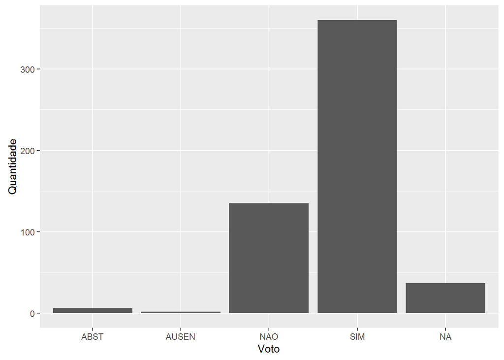

```r
qplot(dados$IMPEACHMENT, xlab = "Voto", ylab = "Quantidade")
```

## Previsões

Serão feitas previsões utilizando três modelos diferentes, são eles: Regressão Logistíca, KNN e Árvore de decisões. Ao final, os resultados obtidos nas previsões feitas por esses três modelos irão ser comparados afim de saber qual deles possuí o melhor desempenho na predição.

### Tratando Dados

Para melhorar os calculos para as previsões, serão considerados apenas os votos SIM e NÃO da coluna do IMPEACHMENT. As váriaveis que serão consideradas nos calculos são UF e partido.

```r
dados <- filter(dados, grepl('SIM|NAO', dados$IMPEACHMENT)) %>% droplevels()

dados$IMPEACHMENT <- as.factor(dados$IMPEACHMENT)
```

### Divisão dos dados

A divisão da amostra de dados será feita de forma aleatória de modo que 75% dos dados sejam utilizados no treino e os 25% restantes serão usados no test.

```r
#criando partições
split <- createDataPartition(y = dados$IMPEACHMENT, p = 0.75, list = F)
treino <- dados[split,]
teste <- dados[-split,]

#adicionando cabeçalho
names(treino) = names(dados)
names(teste) = names(dados)
```

### Regressão Logistíca

#### Treinando modelo

```r
#treinando modelo
logistica <- train(IMPEACHMENT ~ UF + partido, method = 'glm', family = 'binomial', data=treino)

#sumario do modelo
summary(logistica)
```

```
##
## Call:
## NULL
##
## Deviance Residuals:
##      Min        1Q    Median        3Q       Max
## -2.68227  -0.02252   0.00005   0.19162   2.45532
##
## Coefficients: (1 not defined because of singularities)
##                     Estimate Std. Error z value Pr(>|z|)
## (Intercept)        2.109e+01  3.730e+03   0.006   0.9955
## UFAL               3.098e+00  3.711e+00   0.835   0.4038
## UFAM               1.953e+01  5.769e+03   0.003   0.9973
## UFAP              -2.395e+00  2.005e+00  -1.195   0.2323
## UFBA              -2.094e+00  1.523e+00  -1.375   0.1691
## UFCE              -7.765e-01  1.895e+00  -0.410   0.6819
## UFDF               3.314e+00  3.450e+00   0.961   0.3368
## UFES               4.793e+00  2.354e+00   2.037   0.0417 *
## UFGO               4.845e+00  2.308e+00   2.099   0.0358 *
## UFMA               1.614e+00  1.802e+00   0.896   0.3704
## UFMG               4.011e+00  1.721e+00   2.330   0.0198 *
## UFMS               1.568e+00  2.327e+00   0.674   0.5006
## UFMT               3.492e+00  3.175e+00   1.100   0.2714
## UFPA              -4.347e-01  1.538e+00  -0.283   0.7774
## UFPB               9.949e-01  1.690e+00   0.589   0.5560
## UFPE               5.030e-01  1.473e+00   0.341   0.7328
## UFPI              -6.999e-02  1.557e+00  -0.045   0.9641
## UFPR               3.221e+00  1.842e+00   1.749   0.0803 .
## UFRJ               1.446e+00  1.454e+00   0.994   0.3203
## UFRN               3.650e-01  1.903e+00   0.192   0.8479
## UFRO               2.222e+01  7.514e+03   0.003   0.9976
## UFRR               2.174e+01  5.731e+03   0.004   0.9970
## UFRS               3.653e+00  1.778e+00   2.054   0.0400 *
## UFSC               3.883e+00  2.793e+00   1.390   0.1645
## UFSE               3.159e+00  3.624e+00   0.872   0.3834
## UFSP               2.275e+00  1.629e+00   1.397   0.1625
## UFTO              -6.034e-01  1.816e+00  -0.332   0.7398
## partidopcdob      -2.560e+01  3.730e+03  -0.007   0.9945
## partidopdt        -2.441e+01  3.730e+03  -0.007   0.9948
## partidopen        -2.139e+00  1.812e+04   0.000   0.9999
```

[output cut: 21 more lines]

```
## partidoptn        -2.801e+00  1.812e+04   0.000   0.9999
## partidopv         -2.994e+00  7.801e+03   0.000   0.9997
## partidorede       -2.284e+01  3.730e+03  -0.006   0.9951
## partidos.part.    -1.971e+00  1.812e+04   0.000   0.9999
## partidosolidaried -6.838e-01  5.862e+03   0.000   0.9999
## ---
## Signif. codes:  0 '***' 0.001 '**' 0.01 '*' 0.05 '.' 0.1 ' ' 1
##
## (Dispersion parameter for binomial family taken to be 1)
##
##     Null deviance: 437.01  on 371  degrees of freedom
## Residual deviance: 135.58  on 317  degrees of freedom
## AIC: 245.58
##
## Number of Fisher Scoring iterations: 19
```

#### Fazendo Previsões

```r
#realizando predições
predicoes_glm <- predict(logistica, teste)

confusionMatrix(teste$IMPEACHMENT, predicoes_glm)
```

```
## Confusion Matrix and Statistics
##
##           Reference
## Prediction NAO SIM
##        NAO  22  11
##        SIM   4  86
##
##                Accuracy : 0.878
##                  95% CI : (0.8068, 0.9301)
##     No Information Rate : 0.7886
##     P-Value [Acc > NIR] : 0.007392
##
##                   Kappa : 0.667
##  Mcnemar's Test P-Value : 0.121335
##
##             Sensitivity : 0.8462
##             Specificity : 0.8866
##          Pos Pred Value : 0.6667
##          Neg Pred Value : 0.9556
##              Prevalence : 0.2114
##          Detection Rate : 0.1789
##    Detection Prevalence : 0.2683
##       Balanced Accuracy : 0.8664
##
##        'Positive' Class : NAO
##
```

### KNN

#### Treinando modelo

```r
#treinando modelo
ctrl_knn <- trainControl(method = "repeatedcv", number = 10)
knnFit <- train(IMPEACHMENT ~ UF + partido,
                data = treino, method="knn",
                trControl = ctrl_knn,
                preProcess = c("center","scale"),
                tuneGrid = expand.grid(.k = 2:10),
                metric = "Accuracy")

#sumario do modelo
knnFit
```

```
## k-Nearest Neighbors
##
## 372 samples
##  24 predictor
##   2 classes: 'NAO', 'SIM'
##
## Pre-processing: centered (55), scaled (55)
## Resampling: Cross-Validated (10 fold, repeated 1 times)
## Summary of sample sizes: 334, 335, 335, 335, 335, 334, ...
## Resampling results across tuning parameters:
##
##   k   Accuracy   Kappa      Accuracy SD  Kappa SD
##    2  0.7287340  0.3771193  0.05877001   0.15063306
##    3  0.7395448  0.3523175  0.06580543   0.15666208
##    4  0.7503556  0.3745209  0.06665763   0.17372784
##    5  0.7394737  0.3510660  0.06851223   0.16634389
##    6  0.7476529  0.3481802  0.05616005   0.11379601
##    7  0.7798009  0.4376153  0.03571045   0.06841878
##    8  0.8011380  0.4951169  0.03599733   0.09867323
##    9  0.7875533  0.4540871  0.05019594   0.14068974
##   10  0.7876956  0.4460241  0.06268694   0.19834928
##
## Accuracy was used to select the optimal model using  the largest value.
## The final value used for the model was k = 8.
```

#### Fazendo Previsões

```r
#realizando predições
predicoes_knn <- predict(knnFit, teste)

confusionMatrix(teste$IMPEACHMENT, predicoes_knn)
```

```
## Confusion Matrix and Statistics
##
##           Reference
## Prediction NAO SIM
##        NAO  16  17
##        SIM  13  77
##
##                Accuracy : 0.7561
##                  95% CI : (0.6705, 0.829)
##     No Information Rate : 0.7642
##     P-Value [Acc > NIR] : 0.6313
##
##                   Kappa : 0.354
##  Mcnemar's Test P-Value : 0.5839
##
##             Sensitivity : 0.5517
##             Specificity : 0.8191
##          Pos Pred Value : 0.4848
##          Neg Pred Value : 0.8556
##              Prevalence : 0.2358
##          Detection Rate : 0.1301
##    Detection Prevalence : 0.2683
##       Balanced Accuracy : 0.6854
##
##        'Positive' Class : NAO
##
```

#### Treinando modelo

```r
#configurando modelo
grid = expand.grid(.winnow = c(TRUE,FALSE),
                   .trials = c(1,5,10,20,30,40,50,60,70,80,90,100),
                   .model="tree")
ctrl_tree = trainControl(method = "repeatedcv", number = 10, repeats = 10,returnResamp = "all")

#treinando modelo
tree = train(IMPEACHMENT ~ UF + partido,
             data = treino,
             tuneGrid = grid,
             trControl = ctrl_tree,
             method = "C5.0",
             verbose = FALSE,
             metric = "Accuracy")
```

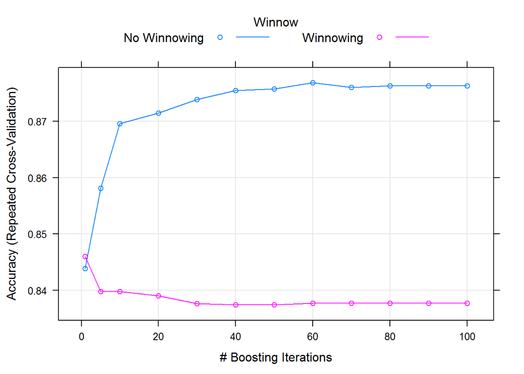

```r
#sumario do modelo
plot(tree)
```

#### Fazendo Previsões

```r
#realizando predições
predicoes_tree <- predict(tree, teste)

confusionMatrix(teste$IMPEACHMENT, predicoes_tree)
```

```
## Confusion Matrix and Statistics
##
##           Reference
## Prediction NAO SIM
##        NAO  20  13
##        SIM   1  89
##
##                Accuracy : 0.8862
##                  95% CI : (0.8164, 0.9364)
##     No Information Rate : 0.8293
##     P-Value [Acc > NIR] : 0.054423
##
##                   Kappa : 0.6724
##  Mcnemar's Test P-Value : 0.003283
##
##             Sensitivity : 0.9524
##             Specificity : 0.8725
##          Pos Pred Value : 0.6061
##          Neg Pred Value : 0.9889
##              Prevalence : 0.1707
##          Detection Rate : 0.1626
##    Detection Prevalence : 0.2683
##       Balanced Accuracy : 0.9125
##
##        'Positive' Class : NAO
##
```

## Conclusões

Dentre o três modelos analisados, o modelo de regressão logistíca e de árvores de decisões tiveram um desempenho melhor em relação ao KNN, ambos possuem uma acurácia elevada, embora o modelo de árvores seja um pouco mais preciso. O modelo de regressão logistica é bastante simples e por causa disso é menos custoso, o KNN e o modelo de árvores gastam mais tempo e mais recusos computacionais devido as diversas repetições que eles promovem para depois pegar o melhor resultado dessas repetições.